# Assignment Linear Regression

Bryant

2022-11-18

```
## notch went outside hinges. Try setting notch=FALSE.
## notch went outside hinges. Try setting notch=FALSE.
## notch went outside hinges. Try setting notch=FALSE.
## notch went outside hinges. Try setting notch=FALSE.
```

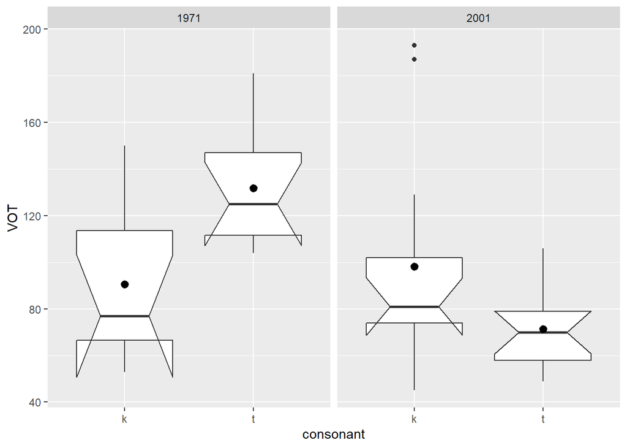

```r
# Plot the data with the interaction included
interaction_plot = data %>%
  ggplot(aes(x=consonant, y = VOT)) +
  geom_boxplot(notch = T) +
  stat_summary(fun = mean) +
  facet_wrap(~year)
interaction_plot
```

```r
# Our naive original model.
m1 <- lm(VOT ~ year + consonant, data = data)
summary(m1)
```

```
##
## Call:
## lm(formula = VOT ~ year + consonant, data = data)
##
## Residuals:
##     Min      1Q  Median      3Q     Max
## -60.069 -23.042  -6.444  12.599 108.734
##
## Coefficients:
##             Estimate Std. Error t value Pr(>|t|)
## (Intercept) 113.0685    10.5511  10.716 1.85e-13 ***
## year2001    -28.8030    11.1955  -2.573   0.0138 *
## consonantt    0.7766    11.0203   0.070   0.9442
## ---
## Signif. codes:  0 '***' 0.001 '**' 0.01 '*' 0.05 '.' 0.1 ' ' 1
##
## Residual standard error: 36.46 on 41 degrees of freedom
## Multiple R-squared:  0.1398, Adjusted R-squared:  0.09785
## F-statistic: 3.332 on 2 and 41 DF,  p-value: 0.04563
```

```r
AIC(m1)
```

```
## [1] 446.2209
```

```r
# Create a second model with the interaction term included.
m2 <- lm(VOT ~ year + consonant + year:consonant, data = data)
summary(m2)
```

```
##
## Call:
## lm(formula = VOT ~ year + consonant + year:consonant, data = data)
##
## Residuals:
##    Min     1Q Median     3Q    Max
## -53.08 -21.36 -11.93  15.67  94.92
##
## Coefficients:
##                     Estimate Std. Error t value Pr(>|t|)
## (Intercept)           90.625     11.495   7.884 1.14e-09 ***
## year2001               7.452     14.610   0.510  0.61281
## consonantt            41.175     15.422   2.670  0.01091 *
## year2001:consonantt  -68.021     20.012  -3.399  0.00154 **
## ---
## Signif. codes:  0 '***' 0.001 '**' 0.01 '*' 0.05 '.' 0.1 ' ' 1
##
## Residual standard error: 32.51 on 40 degrees of freedom
## Multiple R-squared:  0.3326, Adjusted R-squared:  0.2825
## F-statistic: 6.644 on 3 and 40 DF,  p-value: 0.0009535
```

Our R^2 term increased with the addition of the interaction term from .0978 to .2825 which is almost triple what it was before.

```r
AIC(m2)
```

```
## [1] 437.0561
```

As we see our AIC score went down with the added interaction term.

## Test if residuals are normally distributed

```r
# Get the mean of the residuals
cat("Mean of the residuals = ", mean(residuals(m2)))
```

```
## Mean of the residuals =  -1.07955e-15
```

As we can see it our residual mean is very close to 0.

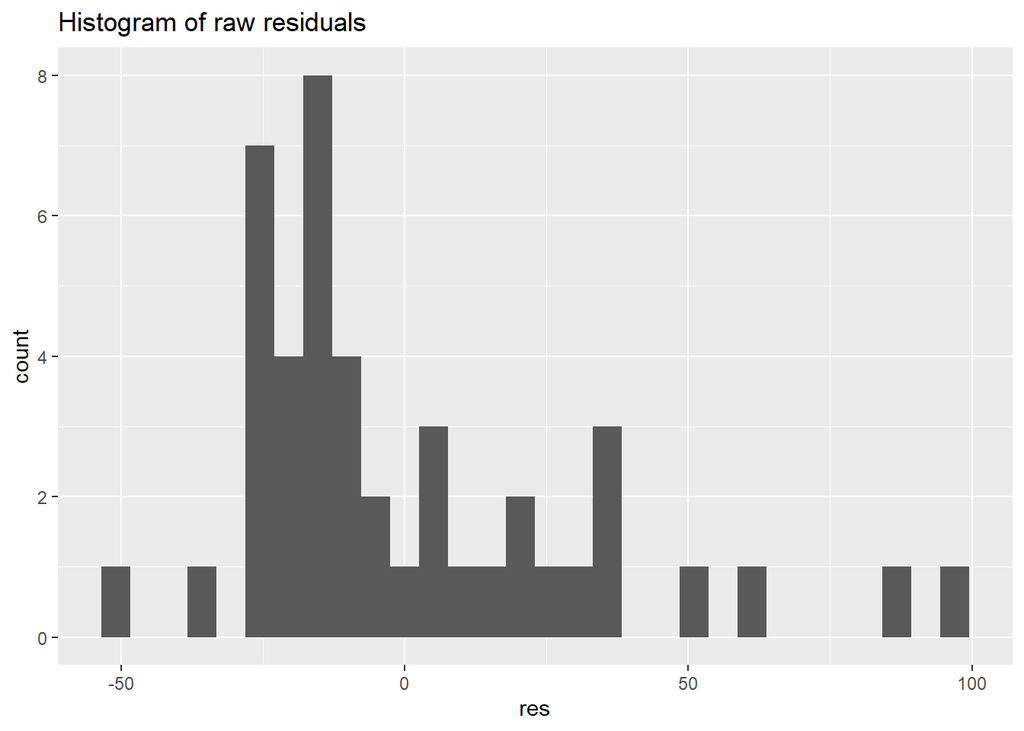

```r
# Show the residuals
tibble(res = residuals(m2)) %>%
  ggplot(aes(res))+
  geom_histogram()+
  ggtitle("Histogram of raw residuals")
```

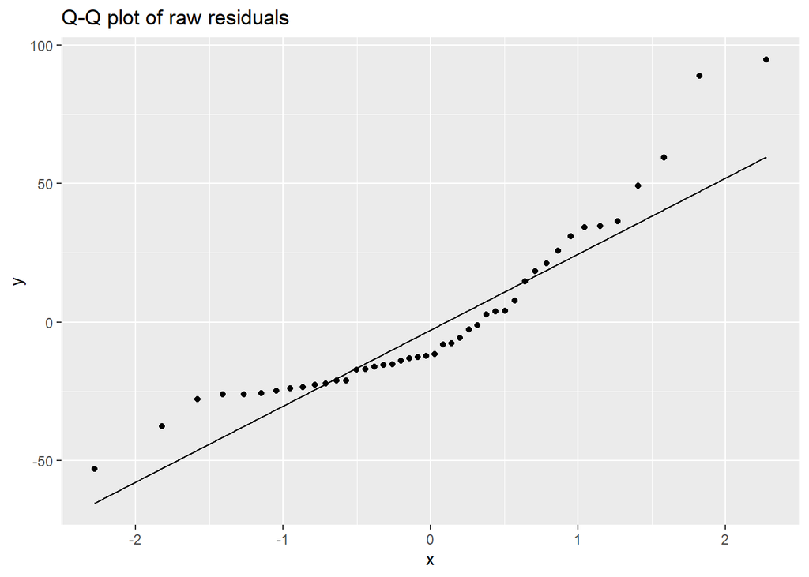

```r
# Get the residuals of our model
res <- residuals(m2)

# Plot the residuals against the ideal distribution
ggplot(tibble(residuals(m2)), aes(sample = res))+
  stat_qq()+
  stat_qq_line()+
  ggtitle("Q-Q plot of raw residuals")
```

```r
# Set up boxcox formula
bc <- MASS::boxcox(data$VOT ~ 1, lambda = seq(-10, 10, 1/100))
```

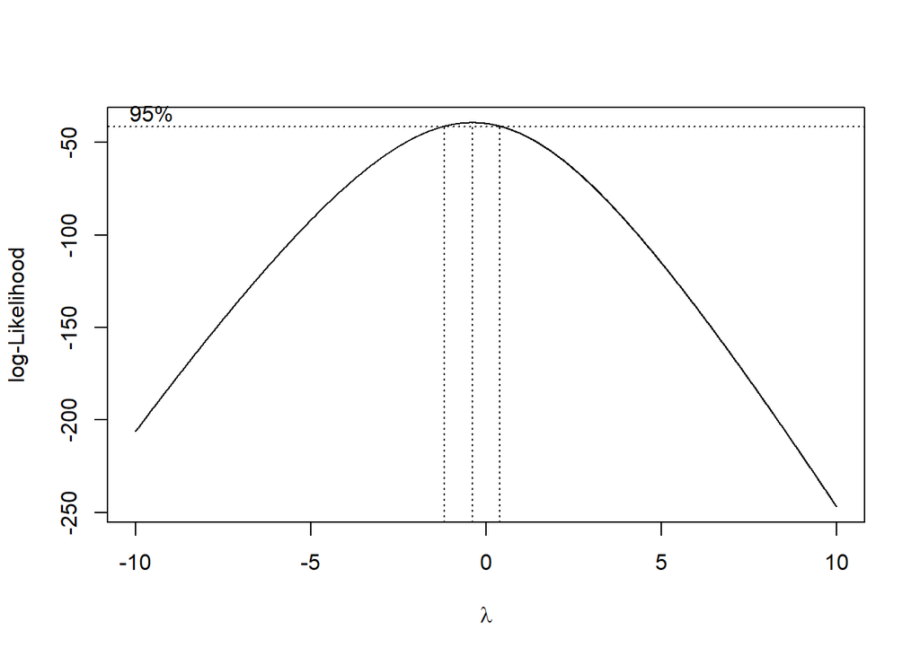

```r
lambda <- bc$x[which.max(bc$y)]

# Make a new model with the box cox formula
m3 <- data %>%
  mutate(bc_vot = (VOT ^ lambda - 1) / lambda) %>%
  lm(bc_vot ~ year + consonant + year:consonant, data = .)
```

```r
cat("Mean of the residuals = ", mean(residuals(m3)))
```

```
## Mean of the residuals =  -2.129903e-18
```

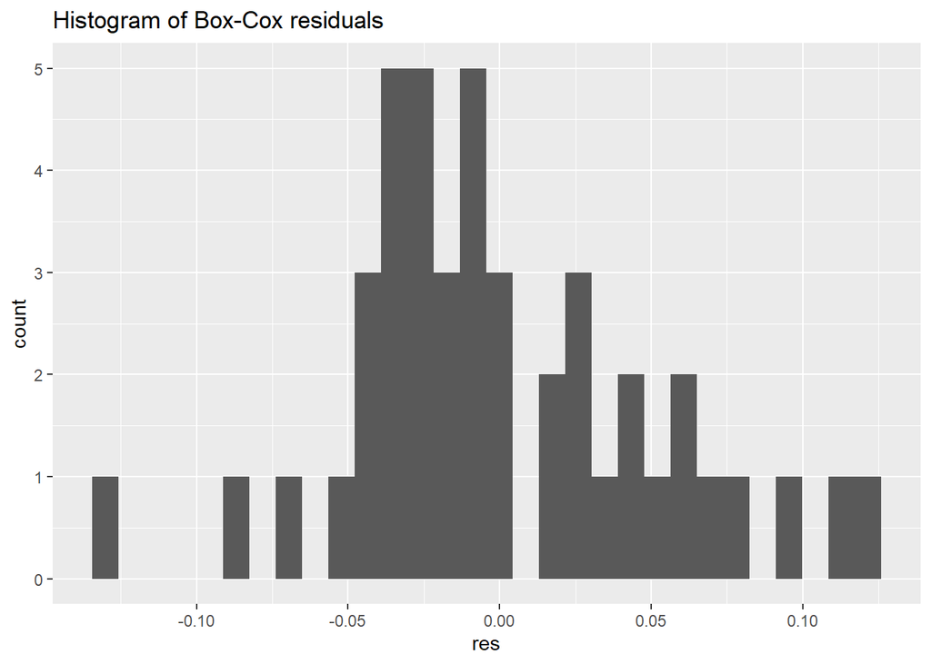

```r
# Create a histogram
tibble(res = residuals(m3)) %>%
  ggplot(aes(res))+
  geom_histogram()+
  ggtitle("Histogram of Box-Cox residuals")
```

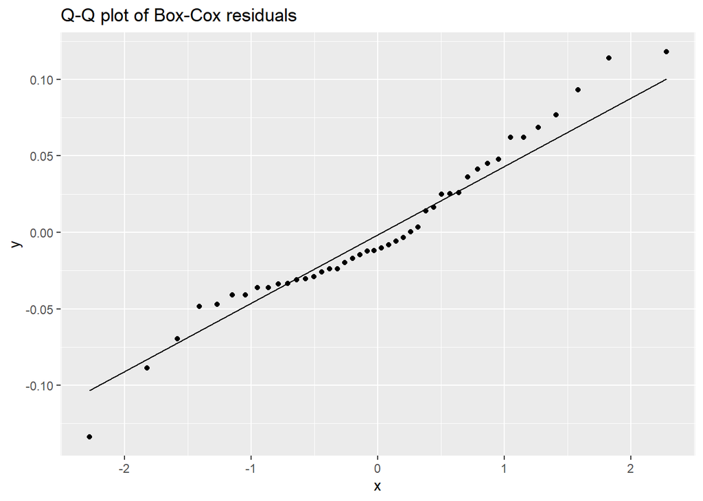

```r
res = residuals(m3)

# Plot our new Box-Cox transformed residuals
ggplot(tibble(res), aes(sample = res))+
  stat_qq()+
  stat_qq_line()+
  ggtitle("Q-Q plot of Box-Cox residuals")
```

```r
library("rstatix")
res = tibble(res)
view(res)
# Run the shapiro test on our residuals to test normality
res %>%
  rstatix::shapiro_test(res)
```

```
## # A tibble: 1 × 3
##   variable statistic     p
##   <chr>        <dbl> <dbl>
## 1 res          0.965 0.195
```

By the Shapiro test since our p value is well over .05 we can say that our data is normally distributed enough.

## Test multicollinearity

We can also confidently say that year and consonant are not collinear based off our visualizations. However our interaction term year:consonant will obviously be partially dependent on both year and consonant.

Just to double check here are our VIFs:

```r
# Show VIF of model (including interaction term)
cat(car::vif(m2))
```

```
## there are higher-order terms (interactions) in this model
## consider setting type = 'predictor'; see ?vif
```

```
## 2.147727 2.469886 3.469886
```

```r
# Show VIF of two predictor variables excluding interaction term
print(car::vif(m2, type='predictor'))
```

```
## GVIFs computed for predictors
```

```
##           GVIF Df GVIF^(1/(2*Df)) Interacts With Other Predictors
## year         1  3               1      consonant             --
## consonant    1  3               1           year             --
```

As we can see our prediction was correct. The VIF including the two terms and the interaction term has signficantly low VIFs for both year and consonant, and even the interaction term isn’t that high between the other two. When we include the interaction term into consideration our vif scores decrease to 1 between year and consonant to show that they are both completely independent of each other.